# Peer-graded Assignment: Prediction Assignment Writeup

Subhanan Ganguli

10 June 2018

## Background

Using devices such as Jawbone Up, Nike FuelBand, and Fitbit it is now possible to collect a large amount of data about personal activity relatively inexpensively. These type of devices are part of the quantified self movement - a group of enthusiasts who take measurements about themselves regularly to improve their health, to find patterns in their behavior, or because they are tech geeks. One thing that people regularly do is quantify how much of a particular activity they do, but they rarely quantify how well they do it. In this project, your goal will be to use data from accelerometers on the belt, forearm, arm, and dumbell of 6 participants. They were asked to perform barbell lifts correctly and incorrectly in 5 different ways. More information is available from the website here: http://web.archive.org/web/20161224072740/http:/groupware.les.inf.puc-rio.br/har (see the section on the Weight Lifting Exercise Dataset).

## Exploratory Data Analysis

- Load Required library

```r
library(ggplot2)
library(caret)
library(rpart)
library(randomForest)
library(rpart.plot)
library(rattle)
library(gbm)
library(e1071)
set.seed(301)
```

- Data loading and processing

```r
Train_Url <- "https://d396qusza40orc.cloudfront.net/predmachlearn/pml-training.csv"
Test_Url <- "https://d396qusza40orc.cloudfront.net/predmachlearn/pml-testing.csv"
download.file(Train_Url, destfile = "pml-training.csv")
download.file(Test_Url,destfile = "pml-testing.csv")
Train_Raw_data <- read.csv("pml-training.csv")
Test_Raw_Data <- read.csv("pml-testing.csv")
dim (Train_Raw_data)
dim(Test_Raw_Data)
```

[output not shown]

“classe” Column is not in Test Data.

```r
col_name <- colnames(Train_Raw_data)== colnames(Test_Raw_Data)
colnames(Train_Raw_data) [col_name==FALSE]
```

```
## [1] "classe"
```

- Create Partition form Training Data to train a model and Predict classe from Test data.

```r
intrain <- createDataPartition(Train_Raw_data$classe, p=0.7, list = FALSE)
TrainData <- Train_Raw_data[intrain, ]
TestData <- Train_Raw_data[-intrain, ]
dim(TrainData)
```

```
## [1] 13737   160
```

```r
dim(TestData)
```

```
## [1] 5885  160
```

- Remove Near Zero values and Data Clean for Train and Test Data set

```r
Near_z_var <- nearZeroVar(TrainData)
TrainData <- TrainData [,-Near_z_var]
TestData <- TestData[,-Near_z_var]
dim(TrainData)
```

```
## [1] 13737   106
```

```r
dim(TestData)
```

```
## [1] 5885  106
```

```r
rm_NA <- sapply(TrainData, function(x) mean(is.na(x))) > 0.95
TrainData <- TrainData[,rm_NA==FALSE]
TestData <- TestData[, rm_NA==FALSE]
dim(TrainData)
```

```
## [1] 13737    59
```

```r
dim(TestData)
```

```
## [1] 5885   59
```

Removing first 5 columns which are not required.

```r
TrainData <- TrainData[,-(1:5)]
TestData <- TestData[,-(1:5)]
dim(TrainData)
dim(TestData)
```

[output not shown]

## Prediction Model

#### Random Forests

3 Fold cross validation

```r
set.seed(101)
RF_ctrl <- trainControl(method = "cv", number = 3, verboseIter = FALSE)
RF_model <- train(classe ~ ., data = TrainData, method="rf", trControl= RF_ctrl)
RF_model$finalModel
```

```
##
## Call:
##  randomForest(x = x, y = y, mtry = param$mtry)
##                Type of random forest: classification
##                      Number of trees: 500
## No. of variables tried at each split: 27
##
##         OOB estimate of  error rate: 0.31%
## Confusion matrix:
##      A    B    C    D    E  class.error
## A 3905    0    0    0    1 0.0002560164
## B    8 2645    4    1    0 0.0048908954
## C    0    6 2390    0    0 0.0025041736
## D    0    0   12 2239    1 0.0057726465
## E    0    2    0    7 2516 0.0035643564
```

```r
predictRF <- predict(RF_model, newdata = TestData)
confMatRF <- confusionMatrix(predictRF, TestData$classe)
confMatRF
```

```
## Confusion Matrix and Statistics
##
##           Reference
## Prediction    A    B    C    D    E
##          A 1673    9    0    0    0
##          B    1 1129    4    0    0
##          C    0    1 1022    2    0
##          D    0    0    0  962    0
##          E    0    0    0    0 1082
##
## Overall Statistics
##
##                Accuracy : 0.9971
##                  95% CI : (0.9954, 0.9983)
##     No Information Rate : 0.2845
##     P-Value [Acc > NIR] : < 2.2e-16
##
##                   Kappa : 0.9963
##  Mcnemar's Test P-Value : NA
##
## Statistics by Class:
##
##                      Class: A Class: B Class: C Class: D Class: E
## Sensitivity            0.9994   0.9912   0.9961   0.9979   1.0000
## Specificity            0.9979   0.9989   0.9994   1.0000   1.0000
## Pos Pred Value         0.9946   0.9956   0.9971   1.0000   1.0000
## Neg Pred Value         0.9998   0.9979   0.9992   0.9996   1.0000
## Prevalence             0.2845   0.1935   0.1743   0.1638   0.1839
## Detection Rate         0.2843   0.1918   0.1737   0.1635   0.1839
## Detection Prevalence   0.2858   0.1927   0.1742   0.1635   0.1839
## Balanced Accuracy      0.9986   0.9951   0.9977   0.9990   1.0000
```

#### Decision Tree

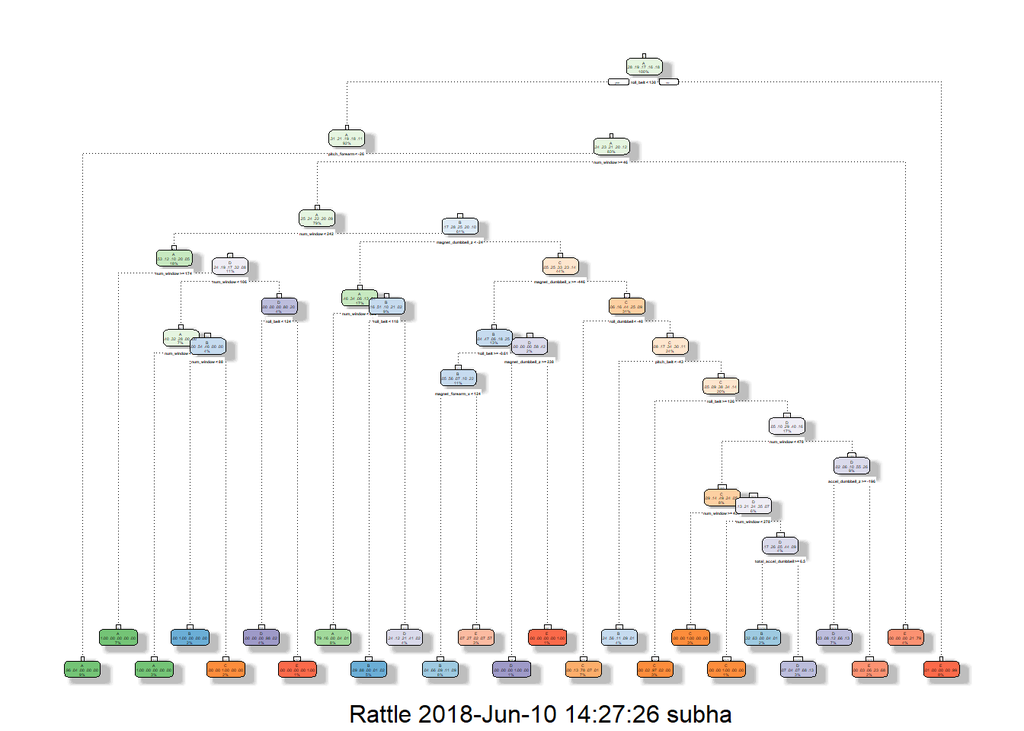

```r
set.seed(101)
DTModle <- rpart(classe ~ ., data=TrainData, method="class")
fancyRpartPlot(DTModle)
```

```r
predictDT <- predict(DTModle,newdata=TestData, type="class")
confMatDT <- confusionMatrix(predictDT,TestData$classe)
confMatDT
```

```
## Confusion Matrix and Statistics
##
##           Reference
## Prediction    A    B    C    D    E
##          A 1441  107    2   15    5
##          B  156  880   73   80   56
##          C    0   48  848   29    0
##          D   64   58   98  761   72
##          E   13   46    5   79  949
##
## Overall Statistics
##
##                Accuracy : 0.8291
##                  95% CI : (0.8192, 0.8386)
##     No Information Rate : 0.2845
##     P-Value [Acc > NIR] : < 2.2e-16
##
##                   Kappa : 0.7843
##  Mcnemar's Test P-Value : < 2.2e-16
##
## Statistics by Class:
##
##                      Class: A Class: B Class: C Class: D Class: E
## Sensitivity            0.8608   0.7726   0.8265   0.7894   0.8771
## Specificity            0.9694   0.9231   0.9842   0.9407   0.9702
## Pos Pred Value         0.9178   0.7068   0.9168   0.7227   0.8690
## Neg Pred Value         0.9460   0.9442   0.9641   0.9580   0.9723
## Prevalence             0.2845   0.1935   0.1743   0.1638   0.1839
## Detection Rate         0.2449   0.1495   0.1441   0.1293   0.1613
## Detection Prevalence   0.2668   0.2116   0.1572   0.1789   0.1856
## Balanced Accuracy      0.9151   0.8479   0.9053   0.8650   0.9237
```

#### Generalized Boosted Model

```r
set.seed(301)
ctrlGM <- trainControl(method = "repeatedcv", number = 5, repeats = 1)
GBModel <- train(classe ~ ., data=TrainData, method = "gbm", trControl = ctrlGM, verbose = FALSE)
GBModel$finalModel
```

```
## A gradient boosted model with multinomial loss function.
## 150 iterations were performed.
## There were 53 predictors of which 42 had non-zero influence.
```

```r
predictGBM <- predict (GBModel, newdata=TestData)
confMatGBM <- confusionMatrix(predictGBM, TestData$classe)
confMatGBM
```

```
## Confusion Matrix and Statistics
##
##           Reference
## Prediction    A    B    C    D    E
##          A 1674   15    0    0    0
##          B    0 1111   14    4    6
##          C    0   10 1011   10    1
##          D    0    3    1  950   12
##          E    0    0    0    0 1063
##
## Overall Statistics
##
##                Accuracy : 0.9871
##                  95% CI : (0.9839, 0.9898)
##     No Information Rate : 0.2845
##     P-Value [Acc > NIR] : < 2.2e-16
##
##                   Kappa : 0.9837
##  Mcnemar's Test P-Value : NA
##
## Statistics by Class:
##
##                      Class: A Class: B Class: C Class: D Class: E
## Sensitivity            1.0000   0.9754   0.9854   0.9855   0.9824
## Specificity            0.9964   0.9949   0.9957   0.9967   1.0000
## Pos Pred Value         0.9911   0.9789   0.9797   0.9834   1.0000
## Neg Pred Value         1.0000   0.9941   0.9969   0.9972   0.9961
## Prevalence             0.2845   0.1935   0.1743   0.1638   0.1839
## Detection Rate         0.2845   0.1888   0.1718   0.1614   0.1806
## Detection Prevalence   0.2870   0.1929   0.1754   0.1641   0.1806
## Balanced Accuracy      0.9982   0.9852   0.9905   0.9911   0.9912
```

## Conclusion

Random Forest is the best mentod for prediction as per Accuracy %. Predict 20 results from Test RAW data.

```r
PT <- predict(RF_model,newdata = Test_Raw_Data)
PT
```

```
##  [1] B A B A A E D B A A B C B A E E A B B B
## Levels: A B C D E
```